# Cover-Climate Relationships Methods Overview

RAP data contain information about fractional cover on a remotely-sensed 30-m grid across CONUS. RAP provides fractional cover for **total trees**, **shrubs**, **bare ground**, and annual and perennial forb and grass cover. We combined values for annual and perennial forb and grass cover into one value for **total herbaceous cover**. While RAP does not have information about cover of needle leaved or broad leaved tree cover or forb, C3 grass, or C4 grass cover, when total tree cover from RAP is zero, we assume that needle leaved and broad leaved tree cover is also zero. Also, when total herbaceous cover from RAP is zero, we assume that forb, C3 grass and C4 grass cover is also zero. We acquired data from the same locations for each year from **2010 - 2024**.

To sub-sample the RAP data, we used a process so that the sampled data was more similar in spatial sampling density to the field-sampled datasets: 1) Start with generating 1 random point location within each 1km^2 dayMet grid cell within the sample region, which is across CONUS excluding locations that are developed, cropland, or water according to LCMAP land use data. - LCMAP data: https://eros.usgs.gov/lcmap/apps/data-downloads We used data from 2021, the most recent year data are available 2) Sample the four closest RAP pixels around those random points and average the values together - this single point represents the ‘observation’ within that dayMet grid cell 3) Then, make the data coarser by averaging values that fall within the same ‘dayMet x 13’ grid cell, which gives a spatial sampling density that is qualitatively similar to that of FIA

Below are maps of RAP data across all years after they’ve been sampled according to the process outlined above: (pending update w/ data from forested regions)

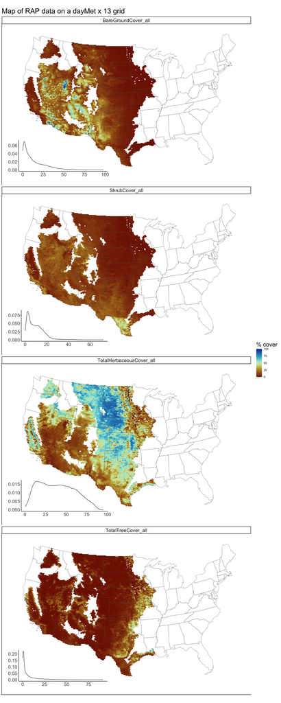

This barplot shows the sample size for each functional group across years in the subsampled RAP data we’re using (pending update w/ data from forested regions)

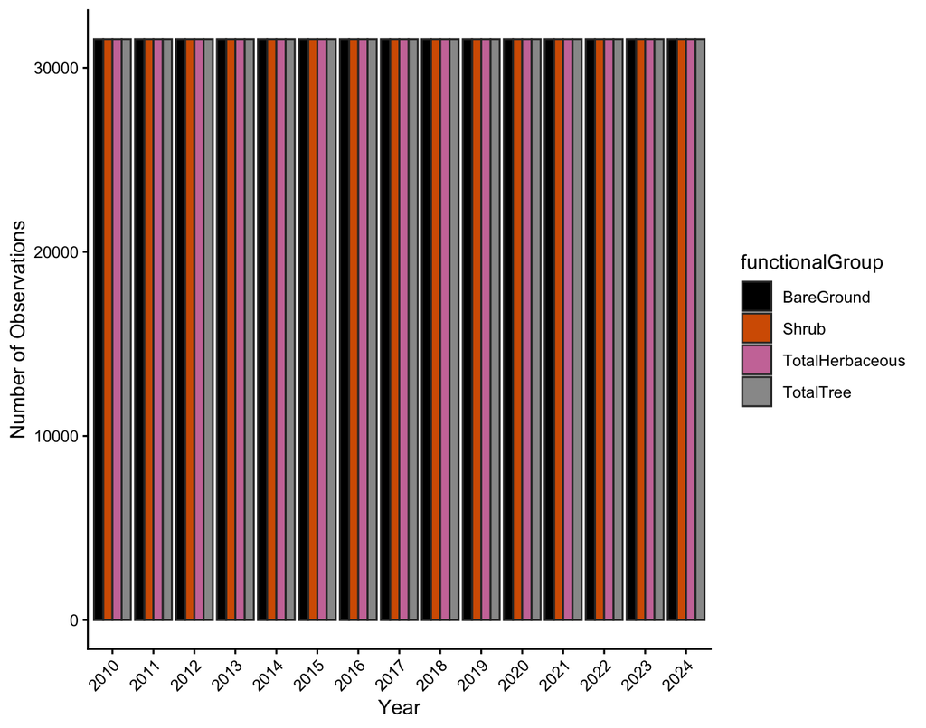

```r
# barplots of # of observations per data type per year
dat_1 %>%
  st_drop_geometry() %>%
  filter(Source == "RAP" & Year >=2010) %>%
  group_by(Year) %>%
  summarize(ShrubCover = sum(!is.na(ShrubCover)),
            TotalTreeCover = sum(!is.na(TotalTreeCover)),
            TotalHerbaceousCover = sum(!is.na(TotalHerbaceousCover)),
            BareGroundCover = sum(!is.na(BareGroundCover))) %>%
  pivot_longer(2:5, values_to = "No_Observations", names_to = "functionalGroup") %>%
  ggplot() +
  geom_col(aes(x = Year, y = No_Observations, fill = functionalGroup), position = "dodge", col = "grey20")  +
   scale_fill_discrete(type = c("#000000", #"#E69F00" ,"#56B4E9", "#009E73", "#F0E442" ,"#0072B2" ,
                                "#D55E00", "#CC79A7", "#999999"),

                        labels = c("BareGround",
                         #"BroadLeavedTree", "C3Grass","C4Grass","Forb", "NeedleLeavedTree",
                                  "Shrub",  "TotalHerbaceous", "TotalTree")
   ) +
  theme(axis.text.x = element_text(angle = 45, hjust = 1)) +
  ylim(c(0,NA)) +
  ylab(c("Number of Observations"))
```

### AIM

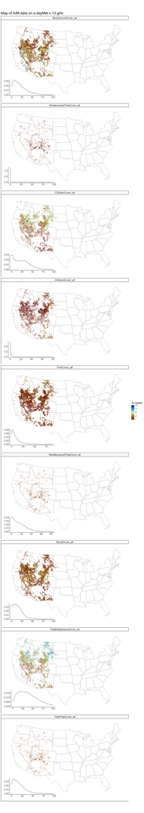

```r
## make figure for LDC
testFigs <- lapply(names(dat_1_RAST$LDC)[4], FUN = function(y) {
  # make a map for this year
           tempFig <-
  ggplot() +
             facet_wrap(~lyr, ncol = 1) +
geom_spatraster(data = dat_1_RAST$LDC[[y]], maxcell = 5e+10) +
  geom_sf(data=cropped_states_2 ,fill=NA ) +
 xlim(-2150000, 2510000) +
 ylim(-2005000, 1000000) +
  coord_sf(datum = st_crs(test_rastTemp)) +
             paletteer::scale_fill_paletteer_c("scico::roma", guide = guide_colorbar(title = "% cover"),
                                               limits = c(0,100), na.value = "white") +
             theme(
                   axis.text = element_blank(),
                   strip.text = element_text(size = 15),
                   title = element_text(size = 18),
                   axis.ticks = element_blank()) +
             ggtitle("Map of AIM data on a dayMet x 13 grid")
  # add an inset showing a density plot
           # get data
           data_inset <- terra::values(dat_1_RAST$LDC[[y]]) %>%
               as_tibble() %>%
               pivot_longer(1:9, names_to = "lyr", values_to = "Cover")

           # make insets
           inset_plots <- data_inset %>%
             split(f = .$lyr) %>%
             purrr::map(~annotation_custom2(
    grob = ggplotGrob(get_inset(.) #+
                        #scale_y_continuous(limits=c(0,105), breaks = c(0, 50, 100))
                      ),
    data = data.frame(lyr=unique(.$lyr)),
    ymin = -2025000, ymax=-1205000, xmin=-2280000, xmax=-180000)
  )

         tempFig2 <- tempFig + inset_plots

           return(tempFig2)
})

testFigs[[1]]
```

This barplot shows the sample size for each functional group across years in the AIM data we’re using:

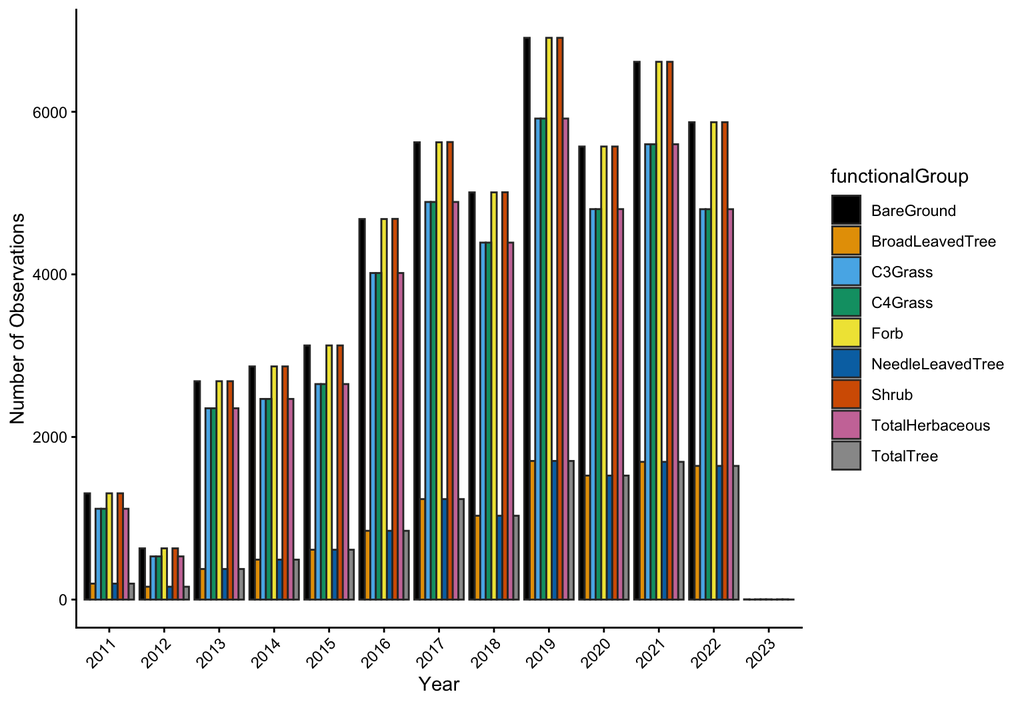

```r
# barplots of # of observations per data type per year
dat_1 %>%
  st_drop_geometry() %>%
  filter(Source == "LDC" & Year >=2010) %>%
  group_by(Year) %>%
  summarize(ShrubCover = sum(!is.na(ShrubCover)),
            TotalTreeCover = sum(!is.na(TotalTreeCover)),
            TotalHerbaceousCover = sum(!is.na(TotalHerbaceousCover)),
           BareGroundCover = sum(!is.na(BareGroundCover)),
            BroadLeavedTreeCover = sum(!is.na(BroadLeavedTreeCover)),
            NeedleLeavedTreeCover = sum(!is.na(NeedleLeavedTreeCover)),
            ForbCover = sum(!is.na(ForbCover)),
            C3GramCover = sum(!is.na(C3GramCover)),
            C4GramCover = sum(!is.na(C4GramCover))
            ) %>%
  pivot_longer(2:10, values_to = "No_Observations", names_to = "functionalGroup") %>%
  ggplot() +
  geom_col(aes(x = Year, y = No_Observations, fill = functionalGroup), position = "dodge", col = "grey20")  +
   scale_fill_discrete(type = c("#000000", "#E69F00" ,"#56B4E9", "#009E73", "#F0E442" ,"#0072B2" ,
                                "#D55E00", "#CC79A7", "#999999"),
                        labels = c("BareGround",
                         "BroadLeavedTree", "C3Grass","C4Grass","Forb", "NeedleLeavedTree",
                                  "Shrub",  "TotalHerbaceous", "TotalTree")
   )+
  theme(axis.text.x = element_text(angle = 45, hjust = 1)) +
  ylim(c(0,NA)) +
  ylab(c("Number of Observations"))
```

### FIA

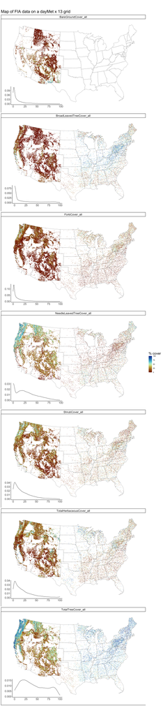

```r
## make figure for FIA
testFigs <- lapply(names(dat_1_RAST$FIA)[4], FUN = function(y) {
  # make a map for this year
           tempFig <-
  ggplot() +
             facet_wrap(~lyr, ncol = 1) +
geom_spatraster(data = dat_1_RAST$FIA[[y]][[c(1:5,8:9)]], maxcell = 5e+10) +
  geom_sf(data=cropped_states_2 ,fill=NA ) +
 xlim(-2150000, 2510000) +
 ylim(-2005000, 1000000) +
  coord_sf(datum = st_crs(test_rastTemp)) +
             paletteer::scale_fill_paletteer_c("scico::roma", guide = guide_colorbar(title = "% cover"),
                                               limits = c(0,100), na.value = "white") +
             theme(
                   axis.text = element_blank(),
                   strip.text = element_text(size = 15),
                   title = element_text(size = 18),
                   axis.ticks = element_blank()) +
             ggtitle("Map of FIA data on a dayMet x 13 grid")
  # add an inset showing a density plot
           # get data
           data_inset <- terra::values(dat_1_RAST$FIA[[y]][[c(1:5,8:9)]]) %>%
               as_tibble() %>%
               pivot_longer(1:7, names_to = "lyr", values_to = "Cover")

           # make insets
           inset_plots <- data_inset %>%
             split(f = .$lyr) %>%
             purrr::map(~annotation_custom2(
    grob = ggplotGrob(get_inset(.) #+
                        #scale_y_continuous(limits=c(0,105), breaks = c(0, 50, 100))
                      ),
    data = data.frame(lyr=unique(.$lyr)),
    ymin = -2025000, ymax=-1205000, xmin=-2280000, xmax=-180000)
  )

         tempFig2 <- tempFig + inset_plots

           return(tempFig2)
})
testFigs[[1]]
```

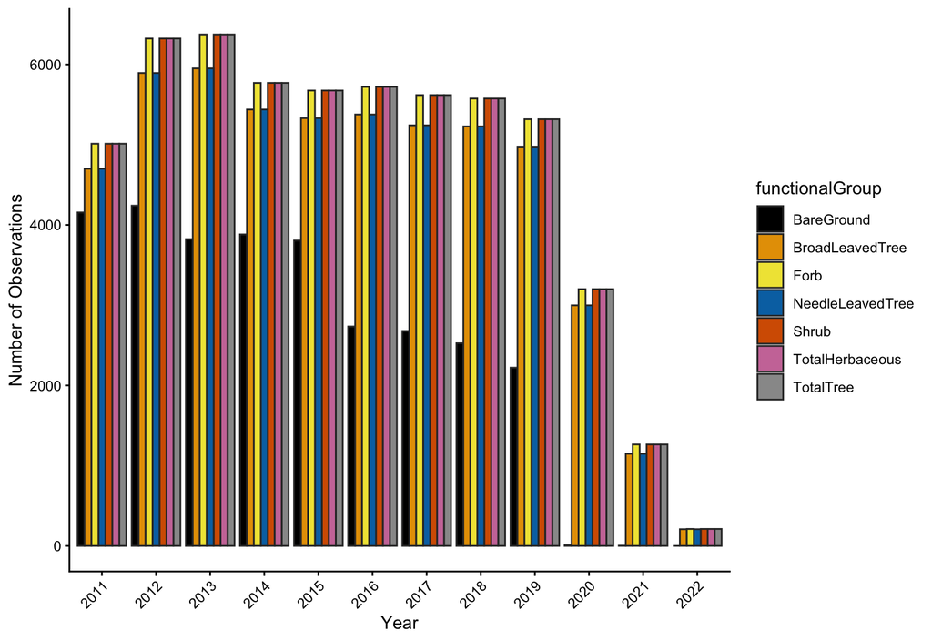

```r
# barplots of # of observations per data type per year
dat_1 %>%
  st_drop_geometry() %>%
  filter(Source == "FIA") %>%
  group_by(Year) %>%
  summarize(ShrubCover = sum(!is.na(ShrubCover)),
            TotalTreeCover = sum(!is.na(TotalTreeCover)),
            TotalHerbaceousCover = sum(!is.na(TotalHerbaceousCover)),
           BareGroundCover = sum(!is.na(BareGroundCover)),
            BroadLeavedTreeCover = sum(!is.na(BroadLeavedTreeCover)),
            NeedleLeavedTreeCover = sum(!is.na(NeedleLeavedTreeCover)),
            ForbCover = sum(!is.na(ForbCover))#,
            #C3GramCover = sum(!is.na(C3GramCover)),
            #C4GramCover = sum(!is.na(C4GramCover))
            ) %>%
  pivot_longer(2:8, values_to = "No_Observations", names_to = "functionalGroup") %>%
  ggplot() +
  geom_col(aes(x = Year, y = No_Observations, fill = functionalGroup), position = "dodge", col = "grey20") +
   scale_fill_discrete(type = c("#000000",
     "#E69F00" ,#"#56B4E9", "#009E73",
     "#F0E442" ,"#0072B2" ,"#D55E00", "#CC79A7", "#999999"),

      labels = c("BareGround",
                         "BroadLeavedTree", #"C3Grass","C4Grass",
                 "Forb", "NeedleLeavedTree",
                                  "Shrub",  "TotalHerbaceous", "TotalTree")
 )+
  theme(axis.text.x = element_text(angle = 45, hjust = 1)) +
  ylim(c(0,NA)) +
  ylab(c("Number of Observations"))
```

### LANDFIRE

The LANDFIRE reference database combines information about vegetation cover from many different sources (state surveys, regional surveys, etc.) It includes information about **total tree cover**, **shrub cover**, **total herbaceous cover**, **needle-leaved tree cover**, **broad-leaved tree cover**, **C3 grass cover**, **C4 grass cover**, and **forb cover**, although not every observation includes information about all functional groups. We use LANDFIRE data from **2000 to 2017**. Below are maps of LANDFIRE data summarized across all years:

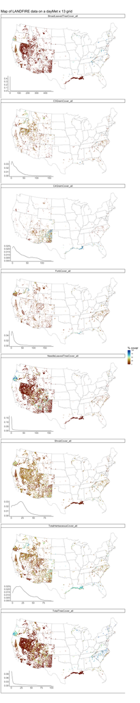

```r
## make figure for LANDFIRE
testFigs <- lapply(names(dat_1_RAST$LANDFIRE)[4], FUN = function(y) {
  # make a map for this year
           tempFig <-
  ggplot() +
             facet_wrap(~lyr, ncol = 1) +
geom_spatraster(data = dat_1_RAST$LANDFIRE[[y]][[c(1:3,5:9)]], maxcell = 5e+10) +
  geom_sf(data=cropped_states_2 ,fill=NA ) +
 xlim(-2150000, 2510000) +
 ylim(-2005000, 1000000) +
  coord_sf(datum = st_crs(test_rastTemp)) +
             paletteer::scale_fill_paletteer_c("scico::roma", guide = guide_colorbar(title = "% cover"),
                                               limits = c(0,100), na.value = "white") +
             theme(
                   axis.text = element_blank(),
                   strip.text = element_text(size = 15),
                   title = element_text(size = 18),
                   axis.ticks = element_blank()) +
             ggtitle("Map of LANDFIRE data on a dayMet x 13 grid")
  # add an inset showing a density plot
           # get data
           data_inset <- terra::values(dat_1_RAST$LANDFIRE[[y]][[c(1:3,5:9)]]) %>%
               as_tibble() %>%
               pivot_longer(1:8, names_to = "lyr", values_to = "Cover")

           # make insets
           inset_plots <- data_inset %>%
             split(f = .$lyr) %>%
             purrr::map(~annotation_custom2(
    grob = ggplotGrob(get_inset(.) #+
                        #scale_y_continuous(limits=c(0,105), breaks = c(0, 50, 100))
                      ),
    data = data.frame(lyr=unique(.$lyr)),
    ymin = -2025000, ymax=-1205000, xmin=-2280000, xmax=-180000)
  )

         tempFig2 <- tempFig + inset_plots

           return(tempFig2)
})
testFigs[[1]]
```

This barplot shows the sample size for each functional group across years in the LANDFIRE data we’re using:

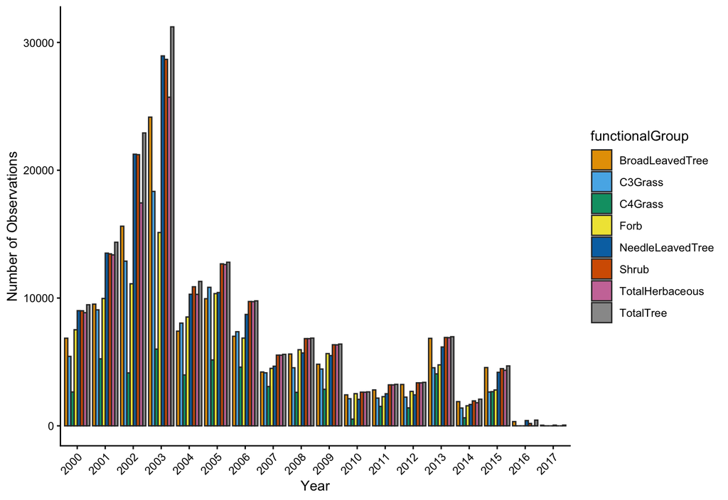

```r
# barplots of # of observations per data type per year
dat_1 %>%
  st_drop_geometry() %>%
  filter(Source == "LANDFIRE") %>%
  group_by(Year) %>%
  summarize(ShrubCover = sum(!is.na(ShrubCover)),
            TotalTreeCover = sum(!is.na(TotalTreeCover)),
            TotalHerbaceousCover = sum(!is.na(TotalHerbaceousCover)),
           # BareGroundCover = sum(!is.na(BareGroundCover)),
            BroadLeavedTreeCover = sum(!is.na(BroadLeavedTreeCover)),
            NeedleLeavedTreeCover = sum(!is.na(NeedleLeavedTreeCover)),
            ForbCover = sum(!is.na(ForbCover)),
            C3GramCover = sum(!is.na(C3GramCover)),
            C4GramCover = sum(!is.na(C4GramCover))
            ) %>%
  pivot_longer(2:9, values_to = "No_Observations", names_to = "functionalGroup") %>%
  ggplot() +
  geom_col(aes(x = Year, y = No_Observations, fill = functionalGroup), position = "dodge", col = "grey20") +
   scale_fill_discrete(type = c(#"#000000",
     "#E69F00" ,"#56B4E9", "#009E73", "#F0E442" ,"#0072B2" ,"#D55E00", "#CC79A7", "#999999"),
                       labels = c(#"BareGround",
                         "BroadLeavedTree", "C3Grass","C4Grass","Forb", "NeedleLeavedTree",
                                  "Shrub",  "TotalHerbaceous", "TotalTree")
 )+
  theme(axis.text.x = element_text(angle = 45, hjust = 1)) +
  ylim(c(0,NA)) +
  ylab(c("Number of Observations"))
```